# Metagenome

Brianna Jeanne Bixler

March 23, 2018

```r
# Install knitr
#install.packages("knitr")
#install.packages("markdown")
```

## PART 1

**mkdir** to create a new directory to store all my files. Next **clone**, this will bring in files from git hub. **cp -r** copy the entire metagenome_assignment directory from the shared folder to my project folder. I will use sequences from P00134 for this project.

```bash
mkdir project1
git clone https://github.com/IBS574/metagenome_assignment.git
cd metagenome_assignment
cp -r /home/Shared/IBS574/TDR-metagenome-practical/* /home/bbixler/project1
```

#### Run FastQC

In order to determine the quality of the samples in the P00134 folder, I ran fastqc on SRR1748708_1.fastq.gz and SRR1748708_2.fastq.gz on the command line of the linuex server (which are the fastq files of the sequencing information).

```bash
fastqc ./SRR1748708_1.fastq.gz
unzip SRR1748708_1_fastqc.zip

fastqc ./SRR1748708_2.fastq.gz
unzip SRR1748708_2_fastqc.zip
```

After the output files are unzipped, and can be easily viewed by navigating the “*.html" files for each in R studio and clicking on those files. This gives a summary report that I saved png files from.

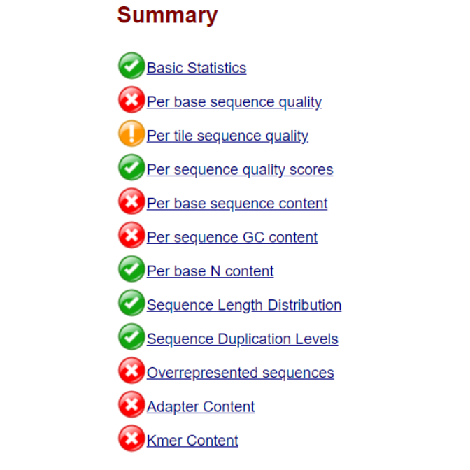

From the summary it is clear that there is a lot of things that did not go quite so well with this sample. I am going to be looking through the SRR1748708_1.fastq.gz file as an example. It is clear that it failed on 6 of the measures, and is iffy on 1. The reverse reads also failed in same 7 sections.

#### Per base sequence quality

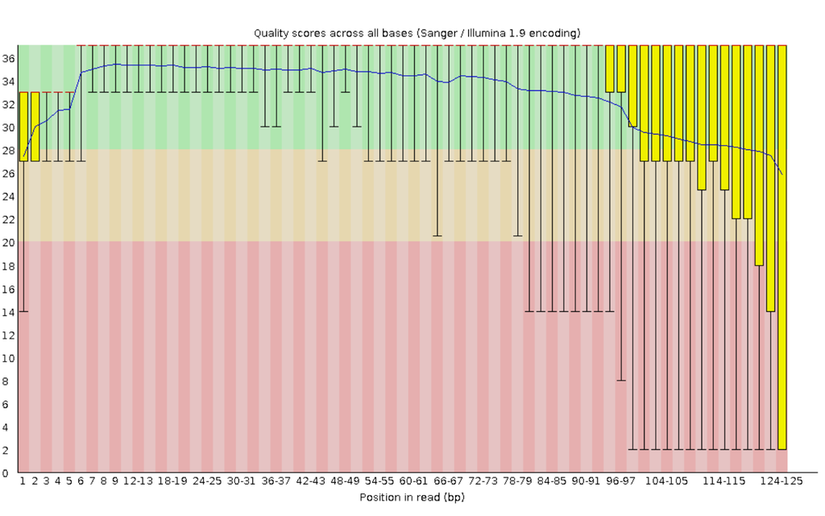

# Per tile sequence quality

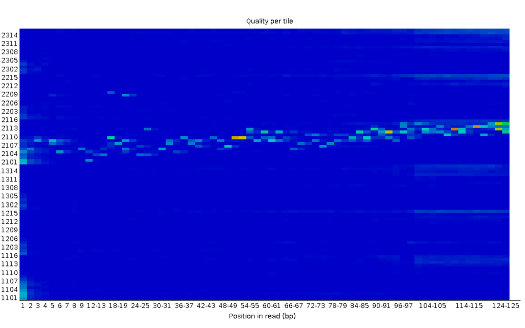

### Per sequence quality score

This looks at the read as individual units and asks if any population of them are lower quality. A score of 30 is good and 1 is very poor. It looks like a high enough percentage of our reads are good.

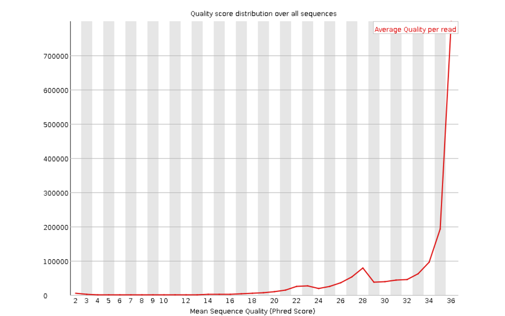

### Per base sequence content

Our sequences failed this metric. For a given position in a read, this plots the proportion of each base. We would expect this to be pretty even because the DNA was randomly fragmented.

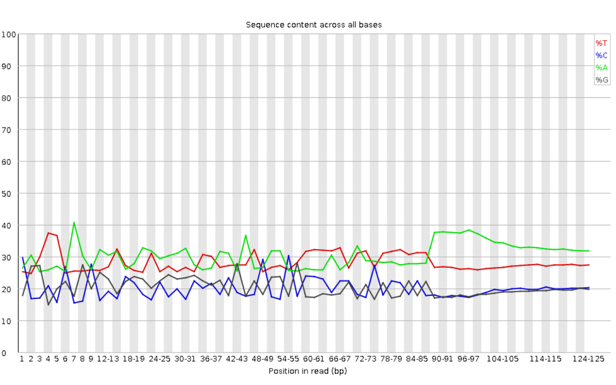

### Per Sequence GC content

This plots the proportion of GC to at any give position along the reads. We would also expect this to be normally distributed, which is why our samples fail.

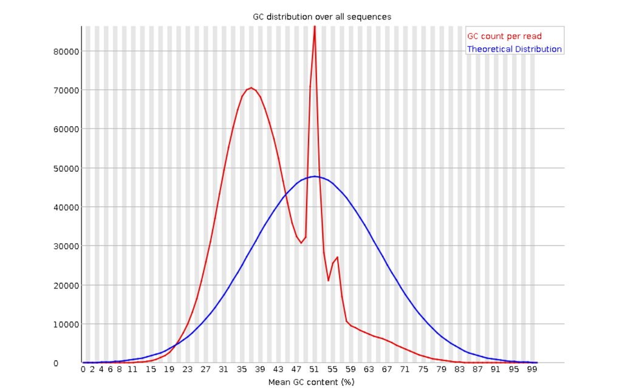

### Per N content

Our sample passed. This one has to do with whether or not a the sequencer is able to make a base call.

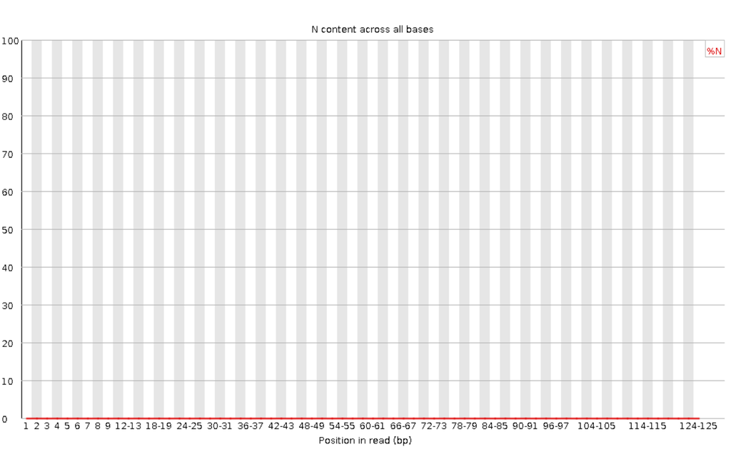

### Sequence Length Distribution

Our sample passed. Most of the reads of our samples were the same length.

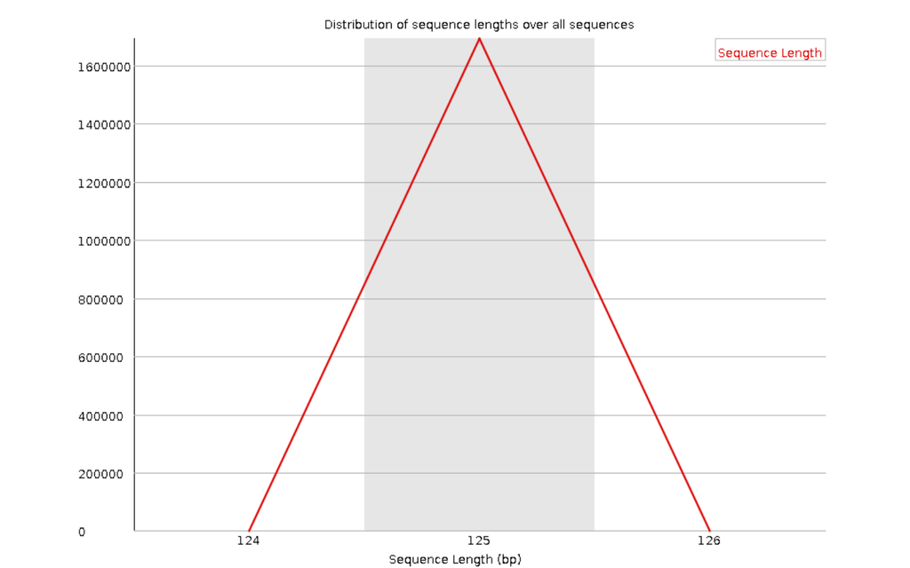

### Sequence duplication Levels

Our sample passed. the sequences that come from this have low duplication rate. When this fails it could be due to a PCR bias from the amplification step.

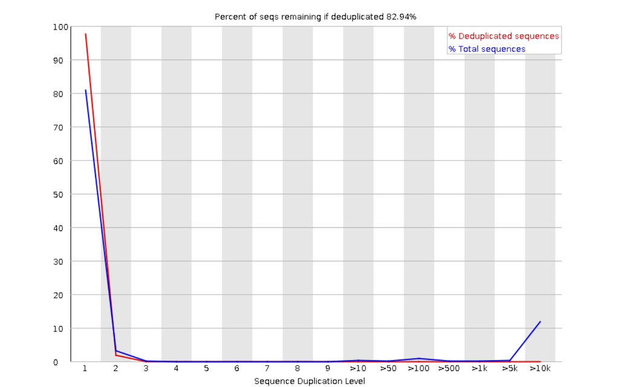

### Overrepresented sequences

It failed. Our library, although there is a low duplication rate has certain sequences that are overrepresented. This could either mean that the sequence is common among the samples, or is it contained with other DNA flooding the system. I thought that maybe the sequence maps to something commn among bacteria, like the 16S. The program thinks that it could be the reverse primer.

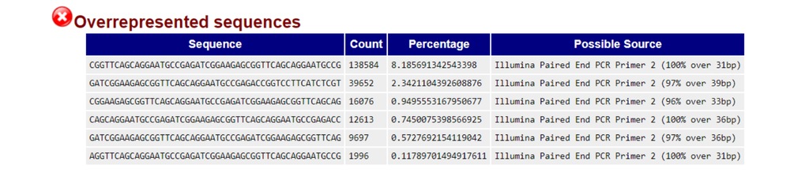

### Adapter Content

It failed this too. There seems to be a high percent adapater in the later half of a population of the reads.

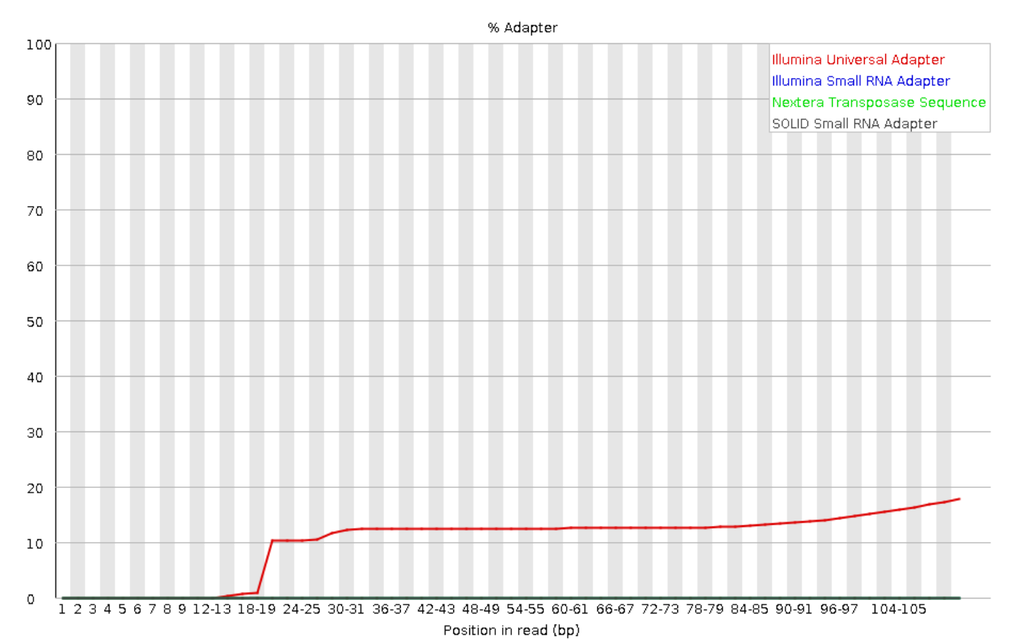

### Kmer Content

It failed. This is another way to look for duplicated sequences that is more senstive to log sequences of poor quality or a partial sequence appearing with in a number of sequences.

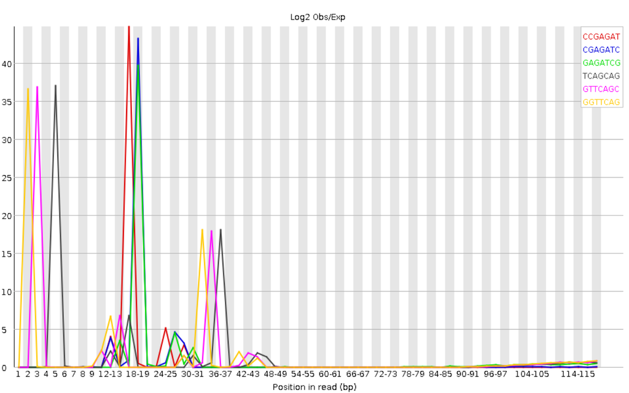

#### Question 2

*How can you get the number and length of the reads in the FASTQ files? (hint: think UNIX). What other information would be useful to put in a report?*

Since the format of fastq files is: Header denoted by “@” Seqence “A,T,G, or C” Line that starts with “+” Quality info with a bunch of symobols including “/”

#### Number of sequences

I will use this in order to answer the question what the number of reads are. I will use the header as a subsitute for the whole segment of information for th sequence. This would not be valid if the fastq is not in the right format, and it has a sequence without a header or a header without a sequence. I choose this instead of the sequence itself because the sequence can start with A,T,G or C and this is also common to soe of the quality lines after the +. For this I first had to unzip the files using the command **gunzip** and making it apply to all files that end iwth “fastq.qz”. The second line with the **grep** will pull the entire line that contains the symbol “@” from the file “SRR1748708_1.fastq”, and then count the number of line with word count per line (**wc -l**).

```bash
gunzip -d *fastq.gz
grep "@" SRR1748708_1.fastq | wc -l
```

output 1693003

```bash
grep "@" SRR1748708_2.fastq | wc -l
```

output 1693003

#### Length of Sequence

From this we can say the each both the files have the same number of headers, suggesting that they have the same number of sequences. The next question I need to answer is if the lines have the same length of sequences. From storing the header information into a file and looking at the names, it seems that the length of each sequence is 125 bp.

To actually count all sequence lines I could do it 4 steps. First I pulled down the header line and the line after with the **-A 1** command from the fastq file and stored that in a file named “test.seq”. Then in the test.seq file, I want to **grep** all line that do not contain characters “@” or “-” with the commans **“[^1]”** and then store that to another file called “only.seq”. After that I want to count the number of characters per line in the only.seq file. For this I used the **awk { print lengt()}** and stored that in a file called “length”. I then calculated the values in “length” using a complicated **awk** command I got straight from stack overflow.

This confirms the information that I gathered from the first 20 or so headers is largely true for the whole document.

```bash
grep "@" -A SRR1748708_1.fastq > test.seq
grep "^[^@-]" test.seq > only.seq
awk '{ print length($0); }' only.seq >length
awk '{s+=$1}END{print "ave:",s/NR}' RS=" " length
```

output ave: 125

#### Double checking

Just checking the number of sequences another way with the other file I made “length”. This also confirms that I probably only put the sequence lines in there.

```bash
wc -l length
```

output 1693003 length

## PART 2

I ran kraken on samples from P00134 in a new directory named “krak_bixler”.

```bash
mkdir krak_bixler
kraken --db /home/Shared/IBS574/TDR-metagenome-practical/minikraken_20141208 --fastq-input --gzip-compressed --paired SRR1748708_1.fastq.
gz SRR1748708_2.fastq.gz --classified-out ./krak_classified_reads > ./kraken_out
kraken-report --db /home/Shared/IBS574/TDR-metagenome-practical/minikraken_20141208 kraken_out > kraken_report
```

There was three output files, “krak_classified_reads”, “kraken_report”, and “kraken_out”. Using these files I have to extract all the sequences from the two files that are identified as *anthrax*.

```bash
grep "Bacillus anthracis" /home/bbixler/project1/krak_bixler/kraken_report > ID
```

output 0.05 769 767 S 1392 Bacillus anthracis 0.00 2 2 - 568206 Bacillus anthracis str. CD C 684

```bash
column -s, -t kraken_out | awk '{if ($3 == "1392") print $2;}' > output
column -s, -t kraken_out | awk '{if ($3 == "568206") print $2;}' >> output
```

```bash
wc -l output
```

output 769 output

This is too much to do by hand, so I wrote a loop to cycle through the list.

#### Looping through output to extract sequences

I am sure you could do this a million ways, but right now I am partial to the **grep** function in bash. For this I figured out that the sequence is only one line directly after the header which can by identified by the ID numbers stored in the file named “output”. Using this I used read in the ID line by line from “output” and used **grep -A 1** to search for the ID pulled and the line that follows after in the “krak_classified_reads” file. I then stored the results in a new file “output.fasta”.

```bash
vi krak_script

#!/bin/sh
for line in $(cat output)
do
        grep -A 1 "$line" /home/bbixler/project1/krak_bixler/krak_classified_reads
done > output.fasta
```

#### run the script

The output file has the sequences that mapped to *anthrax* in the kraken analysis.

```bash
chmod +x krak_script
./krak_script
```

I can now use this file for my blast searches.

### PART 3

For this part I did it on my own R studio. So the first boxes are just me setting up my directories and reading in the file. #### Set directory

```r
setwd("/Users/Brianna Jeanne/Desktop/Informatics")
getwd()
```

```
## [1] "C:/Users/Brianna Jeanne/Desktop/Informatics"
```

#### Packages

install.packages(“dplyr”) install.packages(“raster”) install.packages(“data.table”) install.packages(“ggplot2”) install.packages(“lattice”) #### Libraries

```r
library(dplyr)
library(raster)
library(data.table)
library(ggplot2)
library(lattice)
```

#### Read in file

```r
temp.csv <- read.csv("/Users/Brianna Jeanne/Desktop/Informatics/DataTable5-metaphlan-metadata_v19.csv",stringsAsFactors = FALSE, header = TRUE)
#name <- colnames(temp.csv)
#length(name[30:length(name)]) #1698
```

### Sum of Abundances

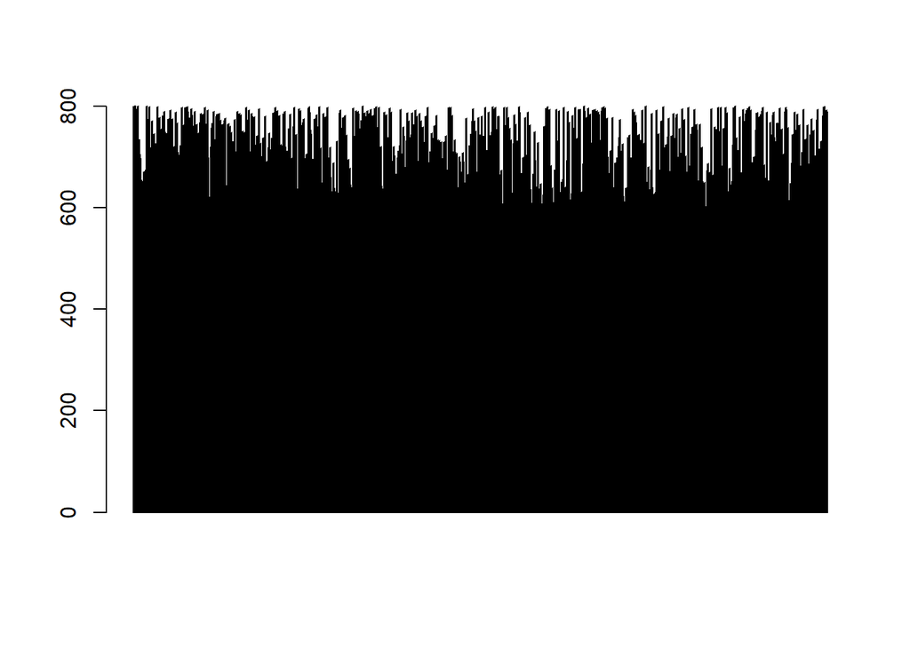

```r
summed <- rowSums(temp.csv[, c(30:nrow(temp.csv))])
barplot(summed)
```

```r
summary(summed)
```

```
##    Min. 1st Qu.  Median    Mean 3rd Qu.    Max.
##     0.0   611.4   666.0   659.6   742.1   800.0
```

## grep for column names

```r
head(grep("g__",colnames(temp.csv)))
```

```
## [1] 35 36 37 38 42 43
```

## list columns that list g_ but not s_

```r
genera <- setdiff(grep("g__",colnames(temp.csv)),grep("s__",colnames(temp.csv)))
head(genera)
```

```
## [1] 35 42 46 52 55 57
```

### checking

```r
head(colnames(temp.csv)[genera])
```

```
## [1] "k__Archaea.p__Euryarchaeota.c__Methanobacteria.o__Methanobacteriales.f__Methanobacteriaceae.g__Methanobrevibacter"
## [2] "k__Archaea.p__Euryarchaeota.c__Methanomicrobia.o__Methanomicrobiales.f__Methanocorpusculaceae.g__Methanocorpusculum"
## [3] "k__Archaea.p__Euryarchaeota.c__Methanomicrobia.o__Methanomicrobiales.f__Methanomicrobiaceae.g__Methanoplanus"
## [4] "k__Archaea.p__Euryarchaeota.c__Methanomicrobia.o__Methanosarcinales.f__Methanosaetaceae.g__Methanosaeta"
## [5] "k__Archaea.p__Euryarchaeota.c__Methanomicrobia.o__Methanosarcinales.f__Methanosarcinaceae.g__Methanolobus"
## [6] "k__Archaea.p__Euryarchaeota.c__Methanomicrobia.o__Methanosarcinales.f__Methanosarcinaceae.g__Methanosarcina"
```

```r
percent <- apply(temp.csv[genera],1,sum)
summary(percent)
```

```
##    Min. 1st Qu.  Median    Mean 3rd Qu.    Max.
##    0.00  100.00  100.00   99.86  100.00  100.00
```

```r
#when only looking at genus level the columns sum to 100% becuase we removed redunacy
```

```r
family <- setdiff(grep("f__",colnames(temp.csv)),grep("g__",colnames(temp.csv)))
percent.f <- apply(temp.csv[family],1,sum)
summary(percent.f)
```

```
##    Min. 1st Qu.  Median    Mean 3rd Qu.    Max.
##    0.00  100.00  100.00   99.86  100.00  100.00
```

```r
king <- setdiff(grep("k__",colnames(temp.csv)),grep("p__",colnames(temp.csv)))
percent.k <- apply(temp.csv[king],1,sum)
summary(percent.k)
```

```
##    Min. 1st Qu.  Median    Mean 3rd Qu.    Max.
##    0.00  100.00  100.00   99.86  100.00  100.00
```

works for other levels, if exclude all the other levels beneath while grepping for the level in interest, the abundance of the columns is equal to 100%.

Given the above, try and answer the following questions.

1. Are any genera called present in the Kraken analysis that were not in the metaphlan (or vice versa)? [QUITE HARD - you will need to google about pattern matching in R]

### Question 2

2. What were the 20 most common bacterial genus discovered in the study (in terms of the number of samples where the genus was identified as > 0% of the microbiome)?

temp.csv <- read.csv(“/home/Shared/IBS574/TDR-metagenome-practical/DataTable5-metaphlan-metadata_v19.csv”,stringsAsFactors = FALSE, header = TRUE)

```r
genera <- setdiff(grep("g__",colnames(temp.csv)),grep("s__",colnames(temp.csv)))
temp.genera <- temp.csv[,genera]

df.bi = data.frame()
for (i in 1:nrow(temp.genera)){
  operator <- as.logical(as.numeric(temp.genera[i,1:ncol(temp.genera)]))
  bi <- lapply(operator, as.numeric)
  df.bi <- rbind(df.bi, bi)}

df.bi[20,5] #should be true, temp.csv[20,35], =1
```

```
## [1] 1
```

```r
df.bi[5,20] #should be false, temp.csv[5,50], =0
```

```
## [1] 0
```

```r
df.bi[1,1] #should be false, temp.csv[1,30], =0
```

```
## [1] 0
```

```r
colnames(df.bi) = colnames(temp.genera)
sum = colSums(df.bi)

rank.df = data.frame(colnames(temp.genera), sum)
index <- order(desc(rank.df$sum))
top.20 = c(index[1:20])
top.names = rownames(rank.df[top.20,])
top.names
```

```
##  [1] "k__Bacteria.p__Proteobacteria.c__Gammaproteobacteria.o__Pseudomonadales.f__Pseudomonadaceae.g__Pseudomonas"
##  [2] "k__Bacteria.p__Proteobacteria.c__Gammaproteobacteria.o__Pseudomonadales.f__Moraxellaceae.g__Acinetobacter"
##  [3] "k__Bacteria.p__Proteobacteria.c__Gammaproteobacteria.o__Xanthomonadales.f__Xanthomonadaceae.g__Stenotrophomonas"
##  [4] "k__Bacteria.p__Proteobacteria.c__Gammaproteobacteria.o__Enterobacteriales.f__Enterobacteriaceae.g__Enterobacter"
##  [5] "k__Bacteria.p__Firmicutes.c__Bacilli.o__Lactobacillales.f__Enterococcaceae.g__Enterococcus"
##  [6] "k__Bacteria.p__Proteobacteria.c__Gammaproteobacteria.o__Enterobacteriales.f__Enterobacteriaceae.g__Escherichia"
##  [7] "k__Bacteria.p__Firmicutes.c__Bacilli.o__Bacillales.f__Bacillaceae.g__Lysinibacillus"
##  [8] "k__Bacteria.p__Proteobacteria.c__Gammaproteobacteria.o__Enterobacteriales.f__Enterobacteriaceae.g__Pantoea"
##  [9] "k__Bacteria.p__Proteobacteria.c__Gammaproteobacteria.o__Enterobacteriales.f__Enterobacteriaceae.g__Klebsiella"
## [10] "k__Bacteria.p__Proteobacteria.c__Betaproteobacteria.o__Burkholderiales.f__Oxalobacteraceae.g__Massilia"
## [11] "k__Bacteria.p__Proteobacteria.c__Alphaproteobacteria.o__Caulobacterales.f__Caulobacteraceae.g__Brevundimonas"
## [12] "k__Bacteria.p__Firmicutes.c__Bacilli.o__Bacillales.f__Bacillaceae.g__Bacillus"
## [13] "k__Bacteria.p__Firmicutes.c__Bacilli.o__Bacillales.f__Bacillales_noname.g__Exiguobacterium"
## [14] "k__Bacteria.p__Bacteroidetes.c__Sphingobacteriia.o__Sphingobacteriales.f__Sphingobacteriaceae.g__Sphingobacterium"
## [15] "k__Bacteria.p__Firmicutes.c__Bacilli.o__Bacillales.f__Staphylococcaceae.g__Staphylococcus"
## [16] "k__Bacteria.p__Firmicutes.c__Bacilli.o__Lactobacillales.f__Leuconostocaceae.g__Leuconostoc"
## [17] "k__Bacteria.p__Actinobacteria.c__Actinobacteria.o__Actinomycetales.f__Dermatophilaceae.g__Dermatophilaceae_unclassified"
## [18] "k__Bacteria.p__Firmicutes.c__Clostridia.o__Clostridiales.f__Clostridiaceae.g__Clostridium"
## [19] "k__Bacteria.p__Firmicutes.c__Bacilli.o__Lactobacillales.f__Aerococcaceae.g__Aerococcus"
## [20] "k__Bacteria.p__Proteobacteria.c__Gammaproteobacteria.o__Oceanospirillales.f__Halomonadaceae.g__Halomonas"
```

### Question 3

3. What was the most common genus found in Brooklyn?

```r
b <- filter(temp.csv, Borough == "Brooklyn")
genera <- setdiff(grep("g__",colnames(temp.csv)),grep("s__",colnames(temp.csv)))
b.g <- b[,genera]
b.g.summed <- colSums(b.g)
answer <- which(b.g.summed== max(b.g.summed))
b.g.summed[answer]
```

```
## k__Bacteria.p__Proteobacteria.c__Gammaproteobacteria.o__Pseudomonadales.f__Pseudomonadaceae.g__Pseudomonas
##                                                                                                   13852.99
```

4. Make a scatterplot of the proportion of the phyla Firmicutes and Bacteroides in each sample. I encourage you to think of other interesting questions in addition to, or instead of, the ones above and include them in your analysis.

I first needed to filter foreach genera, so I used the **grep()** function looking for “p__Firmicutes" in the column names of the origial excel file. This reports back the index at which they occur. I checked the first one to makes sure it was grabbing the rigth columns and I used those as a location vector to grab those columns and put the in a new dataframe. Then I used **xyplot** to plot both bacteria on Y axis in different colors, for any loctaion (which i just designated each culture a number).

```r
firm <- grep("p__Firmicutes", colnames(temp.csv))
df.firm <- temp.csv[,firm]
sum.firm <- rowSums (df.firm, na.rm = FALSE, dims = 1)

bact <- grep("Bacteroide*", colnames(temp.csv))
df.bact <- temp.csv[,bact]
sum.bact <- rowSums (df.bact, na.rm = FALSE, dims = 1)

library(ggplot2)
plot3 <- data.frame(x=1:nrow(temp.csv), Firmicutes=sum.firm, Bacteroides=sum.bact)
head(plot3)
```

```
##   x Firmicutes Bacteroides
## 1 1   73.66562     0.00000
## 2 2  700.00000     0.00000
## 3 3  700.00000     0.00000
## 4 4  600.61678     0.00000
## 5 5    0.00000    10.04529
## 6 6   15.62139    48.81652
```

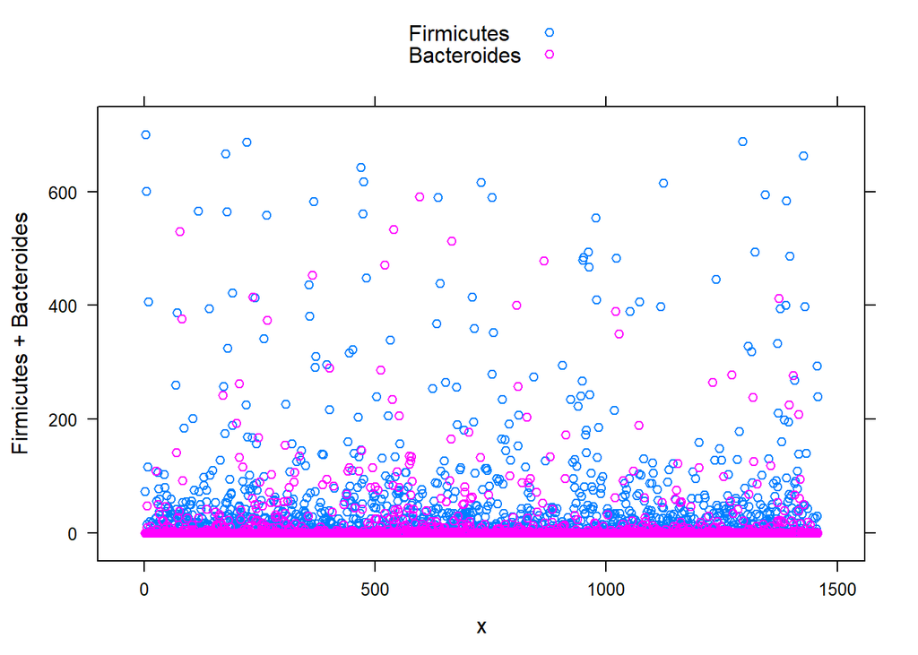

```r
xyplot(Firmicutes+Bacteroides~x,plot3, auto.key=T)
```

### Another Graph

I would prefer this stacked graph but it is impossible to see anthing with so many x values. This would give us a better sense of the proportions and total quantity of the two genera at each location. For this I reformatted the dataset so that I could make a stacked barplot with **barplot()** in the base package.

[figure not shown]

```r
dat <- rbind(sum.firm[500:510], sum.bact[500:510])
barplot(as.matrix(dat), col=c("darkblue","red"), main="10 Cultures")
```

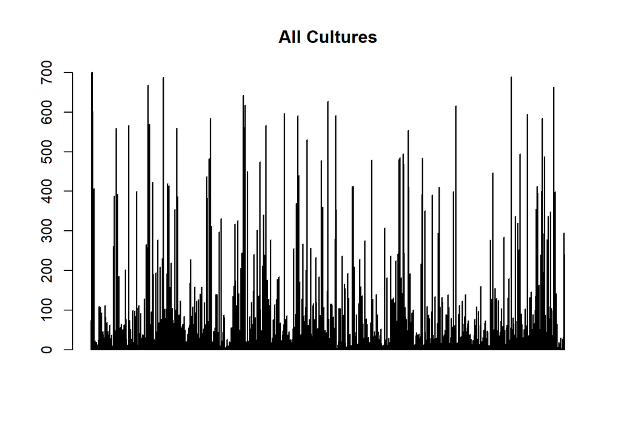

```r
dat1 <- rbind(sum.firm, sum.bact)
barplot(as.matrix(dat1), col=c("darkblue","red"), main="All Cultures")
```

[^1]: ^@-